# Generalized Additive Model (ELMR Chapter 15)

Biostat 200C

Author

Dr. Jin Zhou @ UCLA

Published

June 6, 2024

Display system information and load `tidyverse` and `faraway` packages

```r
library(tidyverse)
library(faraway)
```

## 1 Additional materials about GAM

- [Generalized Additive Models, An Introduction with R, Second Edition](https://www.routledge.com/Generalized-Additive-Models-An-Introduction-with-R-Second-Edition/Wood/p/book/9781498728331) by Simon Wood
- Introduction to Generalized Additive Models with R and mgcv [Git](https://github.com/gavinsimpson/intro-gam-webinar-2020), [Youtube](https://www.youtube.com/watch?v=sgw4cu8hrZM&t=970s)

## 2 Additive models

- For $p$ predictors $x_1, \ldots, x_p$, nonparametric regression takes the form
  $$y = f(x_1, \ldots, x_p) + \epsilon.$$
  For $p$ larger than two or three, it becomes impractical to fit such models due to large sample size requirements.
- A simplified model is the **additive model**
  $$y = \beta_0 + \sum_{j=1}^p f_j(x_j) + \epsilon,$$
  where $f_j$ are smooth functions. Interaction terms are ignored. To incorporate categorical predictors, we can use the model
  $$y = \beta_0 + \sum_{j=1}^p f_j(x_j) + \mathbf{z}^T \boldsymbol{\gamma} + \epsilon,$$
  where $\mathbf{z}$ are categorical predictors.
- There are several packages in R that can fit additive models: `gam`, `mgcv` (included in default installation of R), and `gss`.
- `gam` package uses a **backfitting algorithm** for fitting the additive models.
  1. Initialize $\beta_0 = \bar y$, $f_j(x_j) = \hat \beta_j x_j$ say from the least squares fit.
  2. Cycle throught $j=1,\ldots,p, 1,\ldots,p,\ldots$
     $$f_j = S(x_j, y - \beta_0 - \sum_{i \ne j} f_i(X_i)),$$
     where $S(x,y)$ means the smooth on the data $(x, y)$. User specifies the smoother being used.

  The algorithm is iterated until convergence.
- `mgcv` package employs a penalized smoothing spline approach. Suppose
  $$f_j(x) = \sum_i \beta_i \phi_i(x)$$
  for a family of spline basis functions, $\phi_i$. The roughness penalty $\int [f_j''(x)]^2 \, dx$ translates to the term $\boldsymbol{\beta}_j^T \mathbf{S}_j \boldsymbol{\beta}_j$ for a suitable $\mathbf{S}_j$ that depends on the choice of basis. It then maximizes the penalized log-likelihood
  $$\log L(\boldsymbol{\beta}) - \sum_j \lambda_j \boldsymbol{\beta}_j^T \mathbf{S}_j \boldsymbol{\beta}_j,$$
  where $\lambda_j$ control the amount of smoothing for each variable. Generalized cross-validation (GCV) is used to select the $\lambda_j$s.

## 3 LA ozone concentration

- The response is `O3` (ozone level). The predictors are `temp` (temperature at El Monte), `ibh` (inversion base height at LAX), and `ibt` (inversion top temperature at LAX).

```r
ozone <- as_tibble(ozone) %>% print()
```

```
# A tibble: 330 × 10
      O3    vh  wind humidity  temp   ibh   dpg   ibt   vis   doy
   <dbl> <dbl> <dbl>    <dbl> <dbl> <dbl> <dbl> <dbl> <dbl> <dbl>
 1     3  5710     4       28    40  2693   -25    87   250    33
 2     5  5700     3       37    45   590   -24   128   100    34
 3     5  5760     3       51    54  1450    25   139    60    35
 4     6  5720     4       69    35  1568    15   121    60    36
 5     4  5790     6       19    45  2631   -33   123   100    37
 6     4  5790     3       25    55   554   -28   182   250    38
 7     6  5700     3       73    41  2083    23   114   120    39
 8     7  5700     3       59    44  2654    -2    91   120    40
 9     4  5770     8       27    54  5000   -19    92   120    41
10     6  5720     3       44    51   111     9   173   150    42
# ℹ 320 more rows
```

- Numerical summary.

```r
summary(ozone)
```

```
       O3              vh            wind           humidity
 Min.   : 1.00   Min.   :5320   Min.   : 0.000   Min.   :19.00
 1st Qu.: 5.00   1st Qu.:5690   1st Qu.: 3.000   1st Qu.:47.00
 Median :10.00   Median :5760   Median : 5.000   Median :64.00
 Mean   :11.78   Mean   :5750   Mean   : 4.848   Mean   :58.13
 3rd Qu.:17.00   3rd Qu.:5830   3rd Qu.: 6.000   3rd Qu.:73.00
 Max.   :38.00   Max.   :5950   Max.   :11.000   Max.   :93.00
      temp            ibh              dpg              ibt
 Min.   :25.00   Min.   : 111.0   Min.   :-69.00   Min.   :-25.0
 1st Qu.:51.00   1st Qu.: 877.5   1st Qu.: -9.00   1st Qu.:107.0
 Median :62.00   Median :2112.5   Median : 24.00   Median :167.5
 Mean   :61.75   Mean   :2572.9   Mean   : 17.37   Mean   :161.2
 3rd Qu.:72.00   3rd Qu.:5000.0   3rd Qu.: 44.75   3rd Qu.:214.0
 Max.   :93.00   Max.   :5000.0   Max.   :107.00   Max.   :332.0
      vis             doy
 Min.   :  0.0   Min.   : 33.0
 1st Qu.: 70.0   1st Qu.:120.2
 Median :120.0   Median :205.5
 Mean   :124.5   Mean   :209.4
 3rd Qu.:150.0   3rd Qu.:301.8
 Max.   :350.0   Max.   :390.0
```

- Graphical summary.

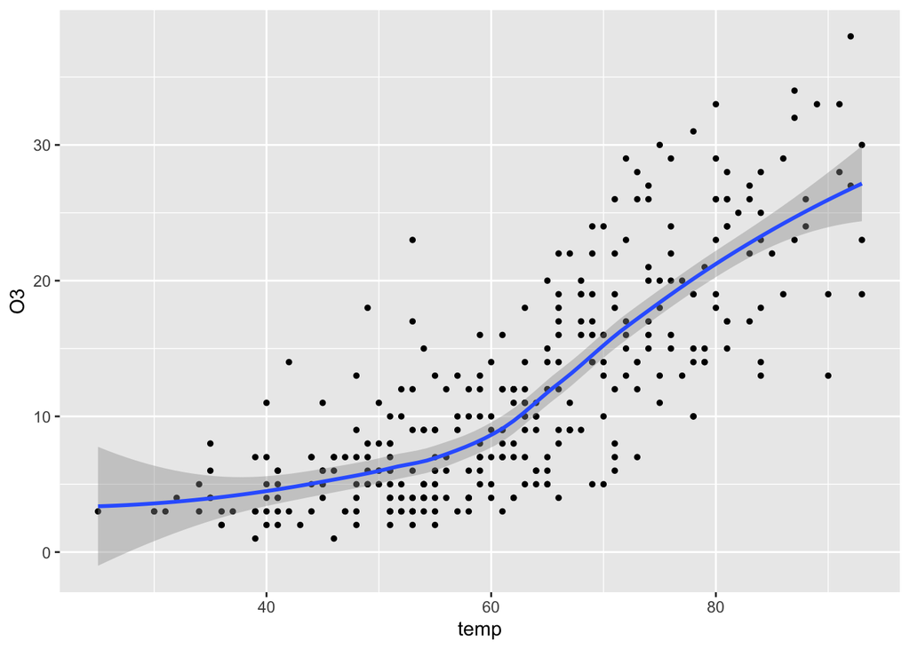

```r
ozone %>%
  ggplot(mapping = aes(x = temp, y = O3)) +
  geom_point(size = 1) +
  geom_smooth()
```

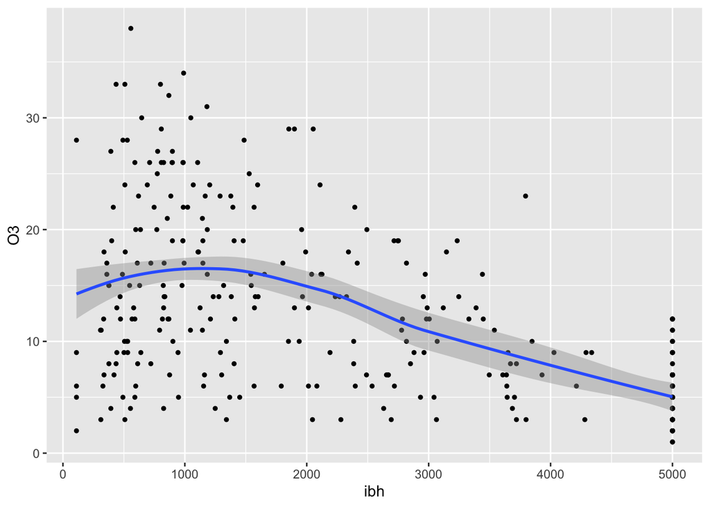

```r
ozone %>%
  ggplot(mapping = aes(x = ibh, y = O3)) +
  geom_point(size = 1) +
  geom_smooth()
```

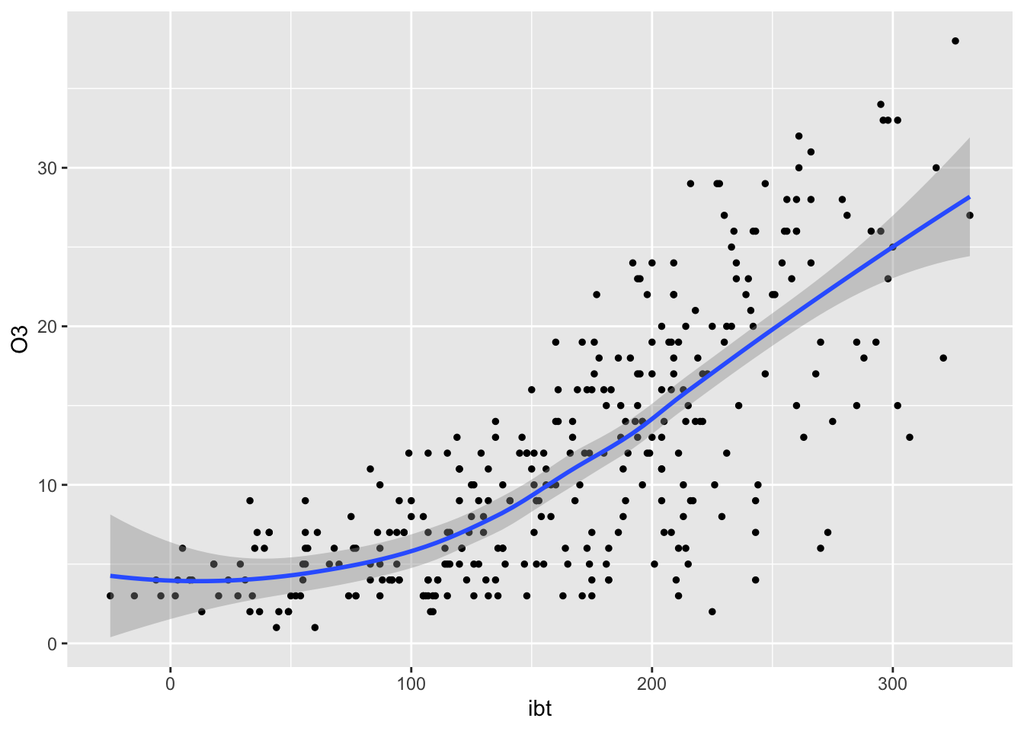

```r
ozone %>%
  ggplot(mapping = aes(x = ibt, y = O3)) +
  geom_point(size = 1) +
  geom_smooth()
```

- As a reference, let’s fit a linear model

```r
olm <- lm(O3 ~ temp + ibh + ibt, data = ozone)
summary(olm)
```

```
Call:
lm(formula = O3 ~ temp + ibh + ibt, data = ozone)

Residuals:
     Min       1Q   Median       3Q      Max
-11.3224  -3.1913  -0.2591   2.9635  13.2860

Coefficients:
              Estimate Std. Error t value Pr(>|t|)
(Intercept) -7.7279822  1.6216623  -4.765 2.84e-06 ***
temp         0.3804408  0.0401582   9.474  < 2e-16 ***
ibh         -0.0011862  0.0002567  -4.621 5.52e-06 ***
ibt         -0.0058215  0.0101793  -0.572    0.568
---
Signif. codes:  0 '***' 0.001 '**' 0.01 '*' 0.05 '.' 0.1 ' ' 1

Residual standard error: 4.748 on 326 degrees of freedom
Multiple R-squared:  0.652, Adjusted R-squared:  0.6488
F-statistic: 203.6 on 3 and 326 DF,  p-value: < 2.2e-16
```

- Additive model using `mgcv`.

```r
library(mgcv)

ammgcv <- gam(O3 ~ s(temp) + s(ibh) + s(ibt), data = ozone)
summary(ammgcv)
```

```
Family: gaussian
Link function: identity

Formula:
O3 ~ s(temp) + s(ibh) + s(ibt)

Parametric coefficients:
            Estimate Std. Error t value Pr(>|t|)
(Intercept)  11.7758     0.2382   49.44   <2e-16 ***
---
Signif. codes:  0 '***' 0.001 '**' 0.01 '*' 0.05 '.' 0.1 ' ' 1

Approximate significance of smooth terms:
          edf Ref.df      F  p-value
s(temp) 3.386  4.259 20.681  < 2e-16 ***
s(ibh)  4.174  5.076  7.338 1.74e-06 ***
s(ibt)  2.112  2.731  1.400    0.214
---
Signif. codes:  0 '***' 0.001 '**' 0.01 '*' 0.05 '.' 0.1 ' ' 1

R-sq.(adj) =  0.708   Deviance explained = 71.7%
GCV = 19.346  Scale est. = 18.72     n = 330
```

Effective degrees of freedom is calculated as the trace of projection matrices. An approximate F test gives the significance of predictors.

- We can exmine the transformations being used.

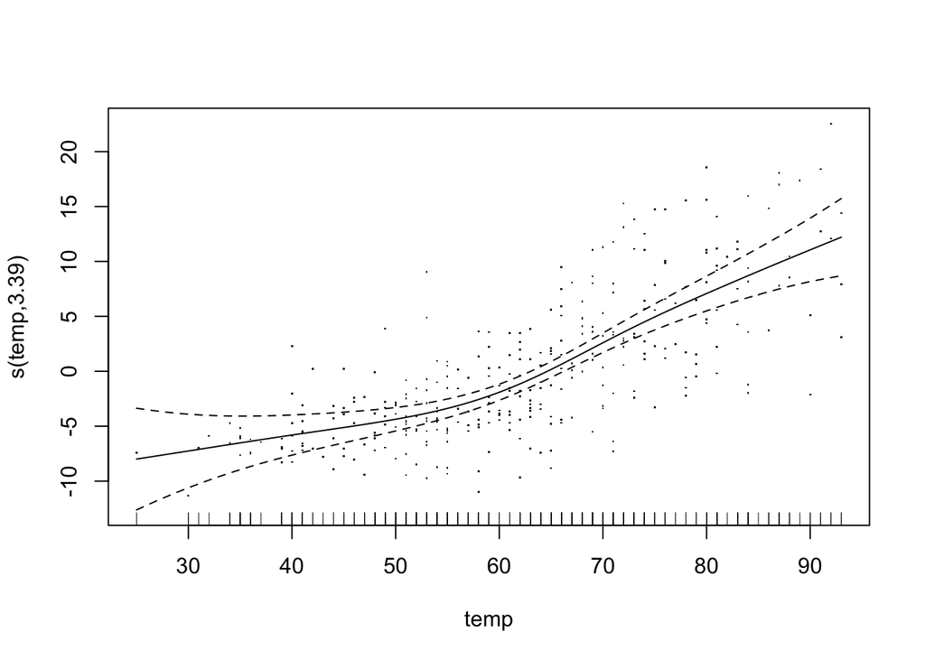

```r
plot(ammgcv, residuals = TRUE, select = 1)
```

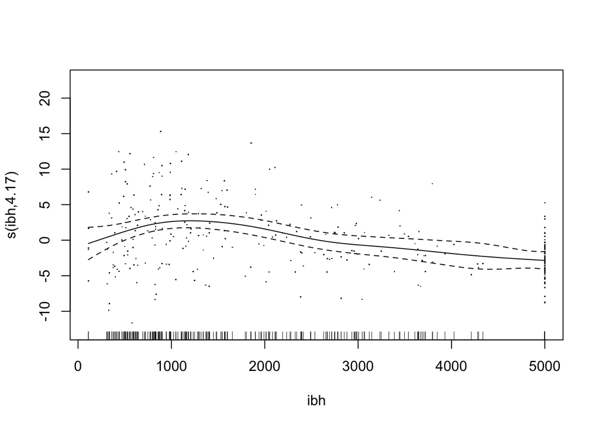

```r
plot(ammgcv, residuals = TRUE, select = 2)
```

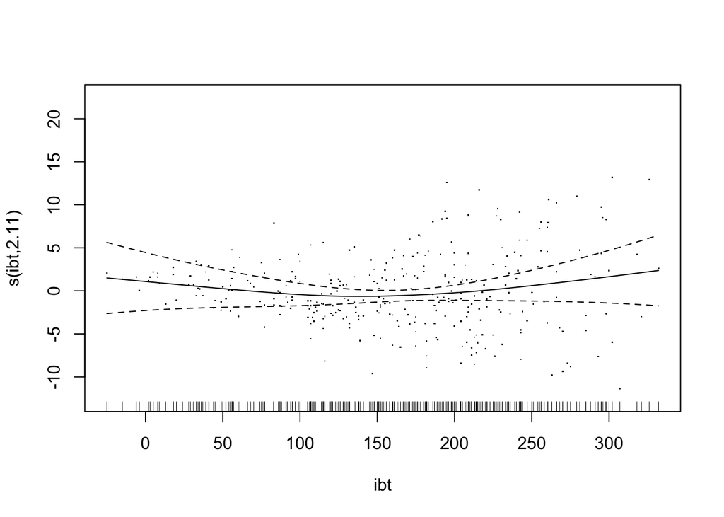

```r
plot(ammgcv, residuals = TRUE, select = 3)
```

- `ibt` is not significant after adjusting for the effects of `temp` and `ibh`, so we drop it in following analysis.
- We can test the significance of the nonlinearity of a predictor by F test.

```r
am1 <- gam(O3 ~ s(temp) + s(ibh), data = ozone)
am2 <- gam(O3 ~    temp + s(ibh), data = ozone)
anova(am2, am1, test = "F")
```

```
Analysis of Deviance Table

Model 1: O3 ~ temp + s(ibh)
Model 2: O3 ~ s(temp) + s(ibh)
  Resid. Df Resid. Dev     Df Deviance      F    Pr(>F)
1    322.74       6950
2    319.11       6054 3.6237   895.98 13.109 3.146e-09 ***
---
Signif. codes:  0 '***' 0.001 '**' 0.01 '*' 0.05 '.' 0.1 ' ' 1
```

- We can include functions of two variables with `mgcv` to incorporate interactions. In the *isotropic* case (same scale), we can impose same smoothing on both variables. In the *anisotropic* case (different scales), we use tensor product to allow different smoothings.

```r
# te(x1, x2) play the role x1 * x2 in regular lm/glm
amint <- gam(O3 ~ te(temp, ibh), data = ozone)
summary(amint)
```

```
Family: gaussian
Link function: identity

Formula:
O3 ~ te(temp, ibh)

Parametric coefficients:
            Estimate Std. Error t value Pr(>|t|)
(Intercept)  11.7758     0.2385   49.38   <2e-16 ***
---
Signif. codes:  0 '***' 0.001 '**' 0.01 '*' 0.05 '.' 0.1 ' ' 1

Approximate significance of smooth terms:
               edf Ref.df     F p-value
te(temp,ibh) 10.45  13.02 61.39  <2e-16 ***
---
Signif. codes:  0 '***' 0.001 '**' 0.01 '*' 0.05 '.' 0.1 ' ' 1

R-sq.(adj) =  0.708   Deviance explained = 71.7%
GCV = 19.439  Scale est. = 18.764    n = 330
```

- We can test the significance of the interactions using F test.

```r
anova(am1, amint, test = "F")
```

```
Analysis of Deviance Table

Model 1: O3 ~ s(temp) + s(ibh)
Model 2: O3 ~ te(temp, ibh)
  Resid. Df Resid. Dev     Df Deviance      F Pr(>F)
1    319.11     6054.0
2    315.98     5977.3 3.1312   76.643 1.3044 0.2725
```

- We can visualize the interactions

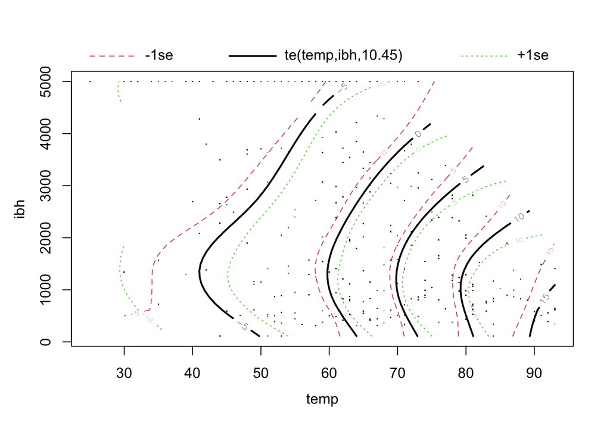

```r
plot(amint, select = 1)
```

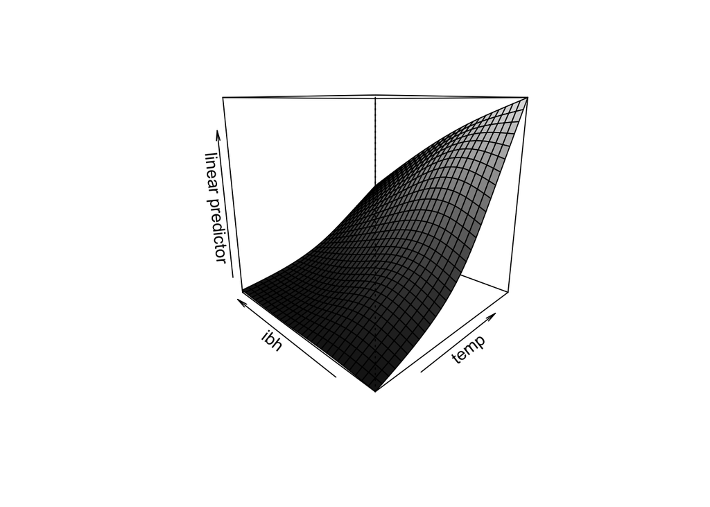

```r
vis.gam(amint, theta = -45, color = "gray")
```

- GAM can be used for prediction.

```r
predict(am1, data.frame(temp = 60, ibh = 2000, ibt = 100), se = T)
```

```
$fit
       1
10.60479

$se.fit
        1
0.7106163
```

```r
# extrapolation
predict(am1, data.frame(temp = 120, ibh = 2000, ibt = 100), se = T)
```

```
$fit
       1
39.11324

$se.fit
       1
5.256285
```

### 3.1 Generalized additive model

- Combining GLM and additive model yields the **generalized additive models (GAMs)**. The systematic component (linear predictor) becomes
  $$\eta = \beta_0 + \sum_{j=1}^p f_j(X_j).$$
- For example, we an fit the `ozone` data using a Poisson additive model. Setting `scale = -1` tells the function to fit overdispersion parameter as well.

```r
gammgcv <- gam(O3 ~ s(temp) + s(ibh) + s(ibt), family = poisson, scale = -1, data = ozone)
summary(gammgcv)
```

```
Family: poisson
Link function: log

Formula:
O3 ~ s(temp) + s(ibh) + s(ibt)

Parametric coefficients:
            Estimate Std. Error t value Pr(>|t|)
(Intercept)  2.29269    0.02305   99.45   <2e-16 ***
---
Signif. codes:  0 '***' 0.001 '**' 0.01 '*' 0.05 '.' 0.1 ' ' 1

Approximate significance of smooth terms:
          edf Ref.df      F p-value
s(temp) 3.816  4.736 16.803  <2e-16 ***
s(ibh)  3.737  4.568 10.594  <2e-16 ***
s(ibt)  1.348  1.623  0.238   0.651
---
Signif. codes:  0 '***' 0.001 '**' 0.01 '*' 0.05 '.' 0.1 ' ' 1

R-sq.(adj) =  0.712   Deviance explained = 72.9%
GCV = 1.5062  Scale est. = 1.4585    n = 330
```

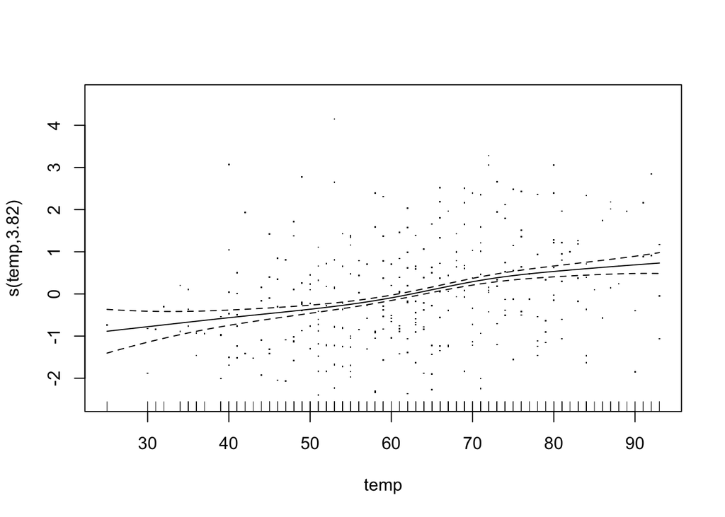

```r
plot(gammgcv, residuals = TRUE, select = 1)
```

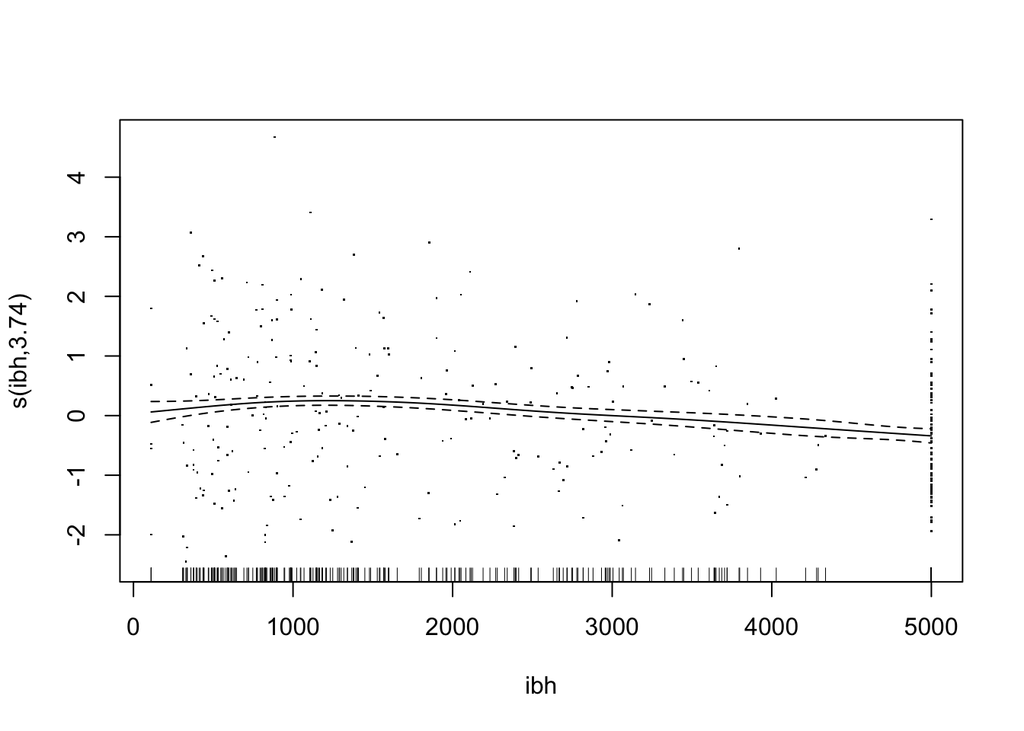

```r
plot(gammgcv, residuals = TRUE, select = 2)
```

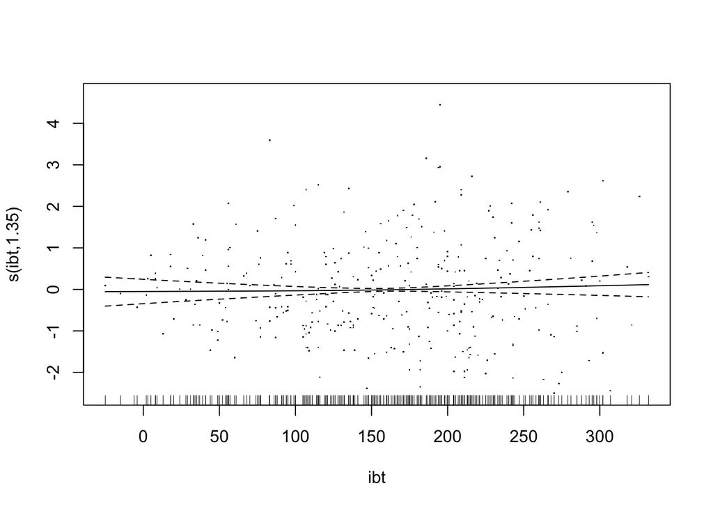

```r
plot(gammgcv, residuals = TRUE, select = 3)
```

## 4 Generalized additive mixed model (GAMM)

- GAMM combine the three major themes in this class.
- Let’s re-analyze the `eplepsy` data from the GLMM chapter.

```r
egamm <- gamm(seizures ~ offset(timeadj) + treat * expind + s(age),
              family   = poisson,
              random   = list(id = ~1),
              data     = epilepsy,
              subset   = (id != 49))
```

```
 Maximum number of PQL iterations:  20
```

```r
summary(egamm$gam)
```

```
Family: poisson
Link function: log

Formula:
seizures ~ offset(timeadj) + treat * expind + s(age)

Parametric coefficients:
              Estimate Std. Error t value Pr(>|t|)
(Intercept)  -4.871650   0.140365 -34.707  < 2e-16 ***
treat        -0.007726   0.195377  -0.040    0.968
expind        4.725542   0.047200 100.117  < 2e-16 ***
treat:expind -0.302384   0.070194  -4.308 2.27e-05 ***
---
Signif. codes:  0 '***' 0.001 '**' 0.01 '*' 0.05 '.' 0.1 ' ' 1

Approximate significance of smooth terms:
       edf Ref.df     F p-value
s(age)   1      1 0.339   0.561

R-sq.(adj) =  0.324
  Scale est. = 1         n = 290
```

## 5 Multivariate adaptive regression splines (MARS) (**not covered in this course**)

- MARS fits data by model
  $$\hat f(x) = \sum_{j=1}^k c_j B_j(x),$$
  where the basis functions $B_j(x)$ are formed from products of terms $[\pm (x_i - t)]_+^q$.
- By default, only additive (first-order) predictors are allowed.

```r
library(earth)

mmod <- earth(O3 ~ ., data = ozone)
summary(mmod)
```

```
Call: earth(formula=O3~., data=ozone)

               coefficients
(Intercept)      14.1595171
h(5860-vh)       -0.0137728
h(wind-3)        -0.3377222
h(54-humidity)   -0.1349547
h(temp-58)        0.2791320
h(1105-ibh)      -0.0033837
h(dpg-10)        -0.0991581
h(ibt-120)        0.0326330
h(150-vis)        0.0231881
h(96-doy)        -0.1105145
h(doy-96)         0.0406468
h(doy-158)       -0.0836732

Selected 12 of 20 terms, and 9 of 9 predictors
Termination condition: Reached nk 21
Importance: temp, humidity, dpg, doy, vh, ibh, vis, ibt, wind
Number of terms at each degree of interaction: 1 11 (additive model)
GCV 14.61004    RSS 4172.671    GRSq 0.7730502    RSq 0.8023874
```

- We can restrict the model size

```r
mmod <- earth(O3 ~ ., ozone, nk = 7)
summary(mmod)
```

```
Call: earth(formula=O3~., data=ozone, nk=7)

            coefficients
(Intercept)   12.3746135
h(58-temp)    -0.1084870
h(temp-58)     0.4962117
h(ibh-1105)   -0.0012172
h(96-doy)     -0.0988262
h(doy-96)     -0.0130345

Selected 6 of 7 terms, and 3 of 9 predictors
Termination condition: Reached nk 7
Importance: temp, ibh, doy, vh-unused, wind-unused, humidity-unused, ...
Number of terms at each degree of interaction: 1 5 (additive model)
GCV 18.3112    RSS 5646.565    GRSq 0.715557    RSq 0.7325855
```

- We can also include second-order (two-way) interaction term. Compare with the additive model approach. There are 9 predictors with 36 possible two-way interaction terms, which is complex to estimate and interpret.

```r
mmod <- earth(O3 ~ ., ozone, nk = 7, degree = 2)
summary(mmod)
```

```
Call: earth(formula=O3~., data=ozone, degree=2, nk=7)

                            coefficients
(Intercept)                   10.0034999
h(58-temp)                    -0.1065473
h(temp-58)                     0.4562717
h(ibh-1105)                   -0.0011576
h(55-humidity) * h(temp-58)   -0.0130712
h(humidity-55) * h(temp-58)    0.0059811

Selected 6 of 7 terms, and 3 of 9 predictors
Termination condition: Reached nk 7
Importance: temp, ibh, humidity, vh-unused, wind-unused, dpg-unused, ...
Number of terms at each degree of interaction: 1 3 2
GCV 18.38791    RSS 5581.691    GRSq 0.7143654    RSq 0.7356579
```

```
 plotmo grid:    vh wind humidity temp    ibh dpg   ibt vis   doy
               5760    5       64   62 2112.5  24 167.5 120 205.5
```

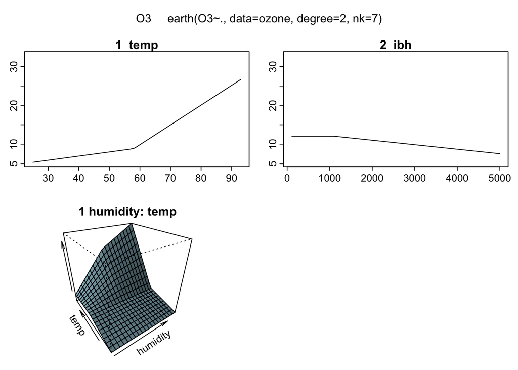

```r
plotmo(mmod)
```